# Warsztaty badawcze - zadanie 3.5

Magdalena Mazurek, Piotr Smuda, Bartosz Topolski

April 6, 2017

# 1. Cel Raportu

Za cel poniższego raportu obraliśmy pokazanie podstawowych statystyk dla zadań, dotyczących wyników i czasów ich rozwiązywania w podziale na kraje i pozycje 1/2/3/4. Aby zawęzić naszą analizę postanowiliśmy skupić się na pięciu wybranych krajach:

1. Polska,
2. Korea Południowa,
3. Stany Zjednoczone,
4. Niemcy,
5. Wielka Brytania.

# 2. Otrzymane wyniki

Wśród otrzymanych wyników rzeczami, na które zwróciliśmy uwagę są:

- Uczniowie dla zadań z nauk przyrodniczych i czytania najwięcej czasu poświęcają dla pozycji 1 oraz 3. Nie przekłada sie to na większą liczbę rozwiązanych zadań.
- Pozycja danego zdania w kwestionariuszu nie wpływa na jego rozwiązanie.
- Uczniowie z Korei i Polski wykonują więcej akcji wraz z pozycją dla zadań z matematyki. Natomiast uczniowie z pozostałych krajów pomiędzy pozycjami wykonują podobną liczbę akcji.

# 3. Analiza i wizualizacja

## 3.1. Wykres średnich czasów rozwiązywania zadania

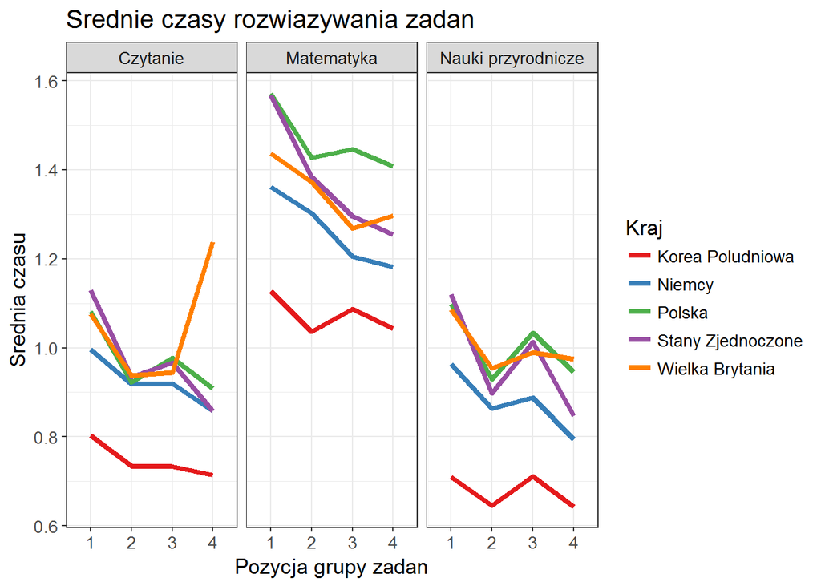

## 3.2. Wykres odestku w pełni rozwiązanych zadań

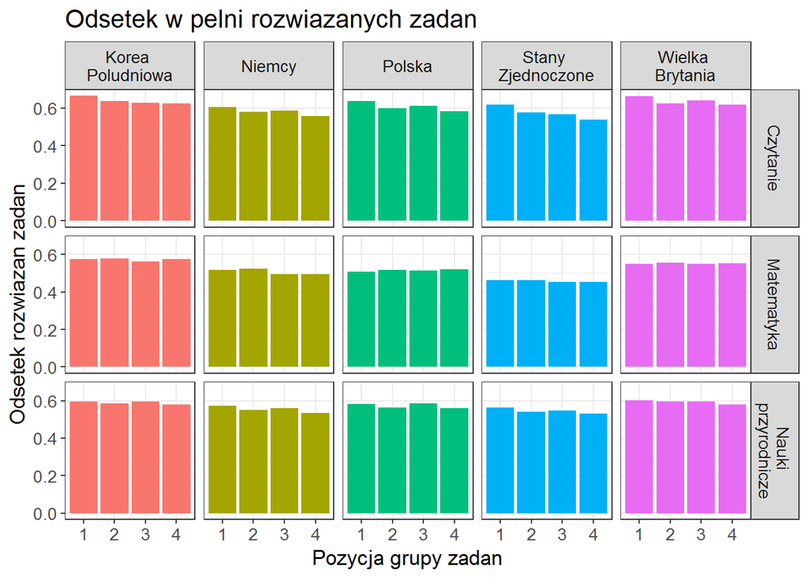

Na powyższym wykresie został przedstawiony odsetek w pełni rozwiązanych zadań w podziale na kraj, rodzaj zadania oraz pozycję zadania w grupie. Widać, że pozycja zadania w tym przypadku nie ma znaczenia, uczniowie rozwiązują w pełni podobną liczbę zadać na początku kwestionariusza, jak i na końcu.

## 3.3. Wykres średniej liczby akcji

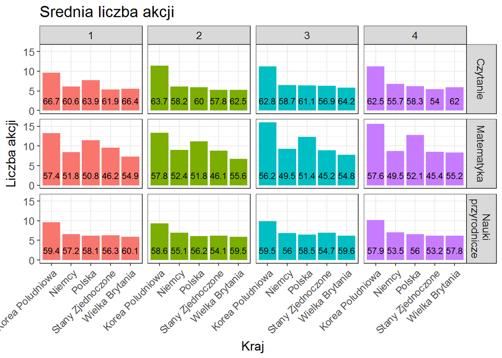

Na powyższym wykresie przedstawiona została średnia liczba akcji w podziale na kraj, rodzaj zadania oraz pozycję zadania w grupie. Podano również procentową wartość w pełni rozwiązanych zadań. Widać, że pomiędzy zadaniami z czytania i nauk przyrodniczych nie ma większych różnic, tzn. pozycja w tych grupach nie ma znaczenia. Dla zadań matematycznych widzimy, że liczba akcji dla uczniów z Korei i Polski rośnie wraz z pozycją.

# 4. Wykorzystany kod

```r
library(dplyr)
library(isotone)
library(knitr)
library(stringi)
library(ggplot2)

load("../data/processed_data/dane_pisa_merged_final_26032017.RDA")

# Zamiana timingu na minuty
dane_pisa_merged_final$timing <- dane_pisa_merged_final$timing / 60000

# Wybór krajów
chosen_countries <- c("POL", "KOR", "USA", "DEU", "GBR")
n <- length(chosen_countries)

# Pozbycie się braków danych
dane_pisa_merged_final <- dane_pisa_merged_final %>%
  filter(!is.na(timing) & !is.na(n.actions) & !is.na(result))
```

## 4.1 Czas rozwiązywania zadań

```r
result_timing <- dane_pisa_merged_final %>% group_by(item_short, CNT, position) %>%
   summarise(min = min(timing, na.rm = TRUE),
          q1 = quantile(timing, 0.25, na.rm = TRUE),
          weighted_median = round(weighted.median(timing, W_FSTUWT), 2),
          weighted_mean = round(weighted.mean(timing, W_FSTUWT, na.rm = TRUE), 2),
          q3 = quantile(timing, 0.75, na.rm = TRUE),
          max = max(timing, na.rm = TRUE))

result_timing_subset <- result_timing %>% filter(CNT %in% chosen_countries)
```

## 4.2. Rodzaje zakończenia rozwiązywania zadań

```r
result_result <- dane_pisa_merged_final %>% group_by(item_short, CNT, position) %>%
   summarise(full_credit = sum(ifelse(is.na(result), 0, result == 1)),
             no_credit = sum(ifelse(is.na(result), 0, result == 0)),
             other = sum(is.na(result)))

result_result_subset <- result_result %>% filter(CNT %in% chosen_countries)
```

## 4.3. Liczba akcji potrzebnych do rozwiązania zadań

```r
result_n_actions <- dane_pisa_merged_final %>% group_by(item_short, CNT, position) %>%
   summarise(min = min(n.actions, na.rm = TRUE),
             q1 = quantile(n.actions, 0.25, na.rm = TRUE),
             weighted_median = round(weighted.median(n.actions, W_FSTUWT), 2),
             weighted_mean = round(weighted.mean(n.actions, W_FSTUWT, na.rm = TRUE), 2),
             q3 = quantile(n.actions, 0.75, na.rm = TRUE),
             max = max(n.actions, na.rm = TRUE))

result_n_actions_subset <- result_n_actions %>% filter(CNT %in% chosen_countries)
```

## 4.4 Kody do wykresow

```r
merged_data <- left_join(result_timing_subset, result_n_actions_subset,
                         by = c("item_short", "CNT", "position"),
                         suffix=c(".time", ".action"))
merged_data <- left_join(merged_data, result_result_subset,
                         by = c("item_short", "CNT", "position"))
merged_data <- merged_data %>%
  mutate(credit_percentage = full_credit/(full_credit + no_credit),
         Zadanie = stri_sub(item_short, 1, 1)) %>%
  group_by(CNT, Zadanie, position)

merged_data$CNT <- factor(merged_data$CNT, levels = unique(merged_data$CNT))
levels(merged_data$CNT)[which(levels(merged_data$CNT) %in% c("GBR", "DEU", "KOR", "POL", "USA"))] <-
  c("Wielka Brytania", "Niemcy", "Korea Południowa", "Polska", "Stany Zjednoczone")

merged_data$Zadanie[which(merged_data$Zadanie == "M")] <- "Matematyka"
merged_data$Zadanie[which(merged_data$Zadanie == "R")] <- "Czytanie"
merged_data$Zadanie[which(merged_data$Zadanie == "S")] <- "Nauki przyrodnicze"
names(merged_data)[which(names(merged_data) == "CNT")] <- "Kraj"

merged_data <- merged_data %>% group_by(Kraj) %>% arrange(desc(Kraj))

merged_data$Kraj <- factor(merged_data$Kraj,
                           levels = c("Korea Poludniowa", "Niemcy", "Polska", "Stany Zjednoczone", "Wielka Brytania"))

merged_data$position <- factor(merged_data$position, levels = unique(merged_data$position))
merged_data <- merged_data[!is.na(merged_data$position),]


# wykres 3.1

data_plot <- merged_data %>% group_by(Kraj, position, Zadanie) %>%
  summarise(mean_time = mean(weighted_mean.time, na.rm=TRUE),
            mean_action = mean(weighted_mean.action, na.rm=TRUE),
            mean_credit = mean(credit_percentage, na.rm=TRUE))

ggplot(data_plot, mapping = aes(x = position, y=mean_time,
                                 group=Kraj, color=Kraj))+
  geom_line(size=1.5)+
  facet_grid(.~Zadanie)+
  ggtitle("Średnie czasy rozwiązywania zadań") +
  xlab("Pozycja grupy zadań") +
  ylab("Średnia czasu") +
  theme_bw() +
  scale_colour_brewer(palette = "Set1", breaks = data_plot$Kraj) +
  theme(text=element_text(size = 13)) +
  theme(plot.title = element_text(hjust = 0))


# wykres 3.2

label_names <- list(
  "Korea Poludniowa" = "Korea \nPoludniowa",
  "Niemcy" = "Niemcy",
  "Polska" = "Polska",
  "Stany Zjednoczone" = "Stany \nZjednoczone",
  "Wielka Brytania" = "Wielka \nBrytania",
  "Czytanie" = "Czytanie",
  "Matematyka" = "Matematyka",
  "Nauki przyrodnicze" = "Nauki \nprzyrodnicze"
)

plot_labeller <- function(variable,value){
  return(label_names[value])
}

ggplot(data_plot, mapping = aes(x = position, y=mean_credit,
                             group=Kraj, fill=Kraj))+
  geom_bar(stat = "identity")+
  facet_grid(Zadanie~Kraj, labeller = plot_labeller)+
  ggtitle("Odsetek w pełni rozwiązanych zadań") +
  xlab("Pozycja grupy zadań") +
  ylab("Odsetek rozwiązań zadań") +
  theme_bw() +
  scale_colour_brewer(palette = "Set1") +
  theme(text=element_text(size = 13)) +
  theme(plot.title = element_text(hjust = 0), legend.position="none")


# wykres 3.3

label_names <- list(
  "1" = "1",
  "2" = "2",
  "3" = "3",
  "4" = "4",
  "Czytanie" = "Czytanie",
  "Matematyka" = "Matematyka",
  "Nauki przyrodnicze" = "Nauki \nprzyrodnicze"
)

plot_labeller <- function(variable,value){
  return(label_names[value])
}

ggplot(data_plot, mapping = aes(x = Kraj, y=mean_action,
                                group=position, fill=position))+
  geom_bar(stat = "identity")+
  geom_text(aes(y=2.5, label=round(mean_credit*100,1)),size=3)+
  facet_grid(Zadanie~position, labeller = plot_labeller)+
  ggtitle("Średnia liczba akcji") +
  xlab("Kraj") +
  ylab("Liczba akcji") +
  theme_bw() +
  scale_colour_brewer(palette = "Set1") +
  theme(text=element_text(size = 13), legend.position="none") +
  theme(plot.title = element_text(hjust = 0),
        axis.text.x = element_text(size=10, hjust=1, vjust = 1, angle=45))
```

# 5. Informacja o sesji

```
 setting  value
 version  R version 3.3.1 (2016-06-21)
 system   x86_64, mingw32
 ui       RTerm
 language (EN)
 collate  English_United States.1252
 tz       Europe/Warsaw
 date     2017-04-07
```

```
Packages ------------------------------------------------------------------
```

```
 package      * version date       source
 assertthat     0.1     2013-12-06 CRAN (R 3.3.1)
 backports      1.0.5   2017-01-18 CRAN (R 3.3.2)
 colorspace     1.3-1   2016-11-18 CRAN (R 3.3.2)
 DBI            0.5-1   2016-09-10 CRAN (R 3.3.2)
 devtools       1.12.0  2016-06-24 CRAN (R 3.3.3)
 digest         0.6.10  2016-08-02 CRAN (R 3.3.2)
 dplyr        * 0.5.0   2016-06-24 CRAN (R 3.3.2)
 evaluate       0.10    2016-10-11 CRAN (R 3.3.2)
 formatR        1.4     2016-05-09 CRAN (R 3.3.2)
 ggplot2      * 2.2.1   2016-12-30 CRAN (R 3.3.2)
 gtable         0.2.0   2016-02-26 CRAN (R 3.3.2)
 htmltools      0.3.5   2016-03-21 CRAN (R 3.3.2)
 isotone      * 1.1-0   2015-07-24 CRAN (R 3.3.2)
 knitr        * 1.14    2016-08-13 CRAN (R 3.3.1)
 labeling       0.3     2014-08-23 CRAN (R 3.3.2)
 lazyeval       0.2.0   2016-06-12 CRAN (R 3.3.2)
 magrittr       1.5     2014-11-22 CRAN (R 3.3.1)
 memoise        1.0.0   2016-01-29 CRAN (R 3.3.3)
 munsell        0.4.3   2016-02-13 CRAN (R 3.3.2)
 nnls           1.4     2012-03-19 CRAN (R 3.3.2)
 plyr           1.8.4   2016-06-08 CRAN (R 3.3.2)
 R6             2.2.0   2016-10-05 CRAN (R 3.3.2)
 RColorBrewer   1.1-2   2014-12-07 CRAN (R 3.3.2)
 Rcpp           0.12.7  2016-09-05 CRAN (R 3.3.2)
 reshape2       1.4.2   2016-10-22 CRAN (R 3.3.2)
 rmarkdown      1.3     2016-12-21 CRAN (R 3.3.1)
 rprojroot      1.2     2017-01-16 CRAN (R 3.3.3)
 scales         0.4.1   2016-11-09 CRAN (R 3.3.2)
 stringi      * 1.1.2   2016-10-01 CRAN (R 3.3.1)
 stringr        1.1.0   2016-08-19 CRAN (R 3.3.1)
 tibble         1.2     2016-08-26 CRAN (R 3.3.2)
 withr          1.0.2   2016-06-20 CRAN (R 3.3.3)
 yaml           2.1.13  2014-06-12 CRAN (R 3.3.2)
```